# Harvard Data Science Professional - Linear Regression

```r
# add 2002 salary of each player
players <- Salaries %>%
  filter(yearID == 2002) %>%
  select(playerID, salary) %>%
  right_join(players, by="playerID")

# add defensive position
position_names <- c("G_p","G_c","G_1b","G_2b","G_3b","G_ss","G_lf","G_cf","G_rf")
tmp_tab <- Appearances %>%
  filter(yearID == 2002) %>%
  group_by(playerID) %>%
  summarize_at(position_names, sum) %>%
  ungroup()
pos <- tmp_tab %>%
  select(position_names) %>%
  apply(., 1, which.max)
```

```
## Note: Using an external vector in selections is ambiguous.
## i Use `all_of(position_names)` instead of `position_names` to silence this message.
## i See <https://tidyselect.r-lib.org/reference/faq-external-vector.html>.
```

```r
players <- data_frame(playerID = tmp_tab$playerID, POS = position_names[pos]) %>%
  mutate(POS = str_to_upper(str_remove(POS, "G_"))) %>%
  filter(POS != "P") %>%
  right_join(players, by="playerID") %>%
  filter(!is.na(POS)  & !is.na(salary))
# add players' first and last names
players <- Master %>%
  select(playerID, nameFirst, nameLast, debut) %>%
  mutate(debut = as.Date(debut)) %>%
  right_join(players, by="playerID")

# top 10 players
players %>% select(nameFirst, nameLast, POS, salary, R_hat) %>%
  arrange(desc(R_hat)) %>%
  top_n(10)
```

```
##    nameFirst    nameLast POS   salary R_hat
## 1      Barry       Bonds  LF 15000000  9.05
## 2       Todd      Helton  1B  5000000  8.23
## 3      Manny     Ramirez  LF 15462727  8.20
## 4      Sammy        Sosa  RF 15000000  8.19
## 5      Larry      Walker  RF 12666667  8.15
## 6      Jason      Giambi  1B 10428571  7.99
## 7    Chipper       Jones  LF 11333333  7.64
## 8      Brian       Giles  LF  8063003  7.57
## 9     Albert      Pujols  LF   600000  7.54
## 10     Nomar Garciaparra  SS  9000000  7.51
```

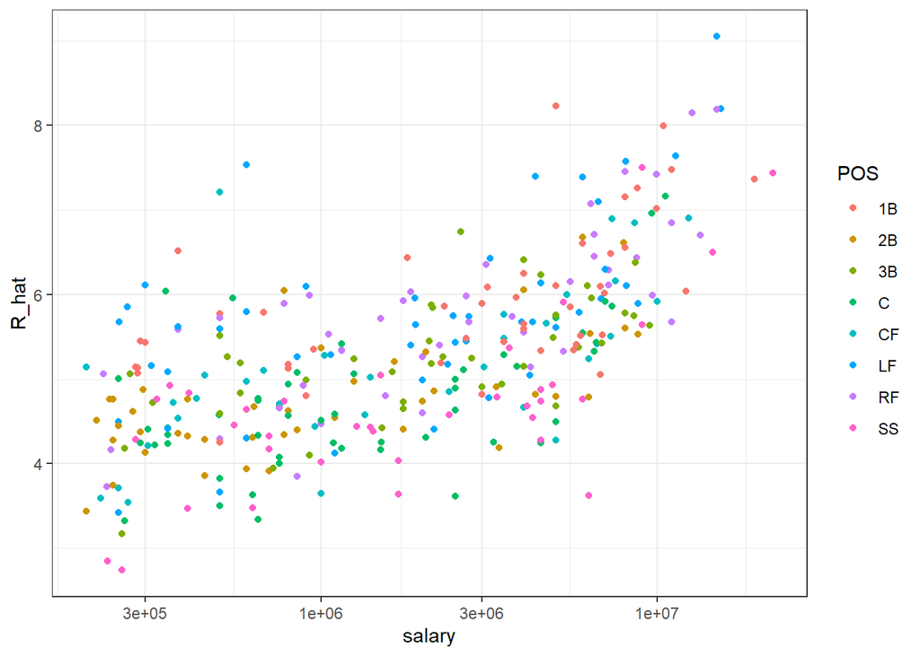

```r
# players with a higher metric have higher salaries
players %>% ggplot(aes(salary, R_hat, color = POS)) +
  geom_point() +
  scale_x_log10()
```

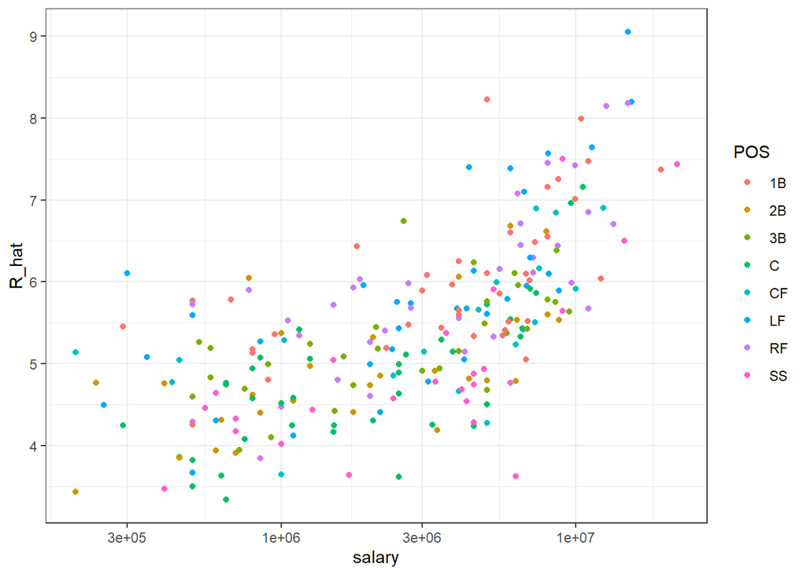

```r
# remake plot without players that debuted after 1998
if(!require(lubridate)) install.packages("lubridate")
library(lubridate)
players %>% filter(year(debut) < 1998) %>%
 ggplot(aes(salary, R_hat, color = POS)) +
  geom_point() +
  scale_x_log10()
```

## Building a Better Offensive Metric for Baseball: Linear Programming

A way to actually pick the players for the team can be done using what computer scientists call linear programming. Although we don’t go into this topic in detail in this course, we include the code anyway:

```r
if(!require(reshape2)) install.packages("reshape2")
if(!require(lpSolve)) install.packages("lpSolve")
library(reshape2)
library(lpSolve)

players <- players %>% filter(debut <= "1997-01-01" & debut > "1988-01-01")
constraint_matrix <- acast(players, POS ~ playerID, fun.aggregate = length)
npos <- nrow(constraint_matrix)
constraint_matrix <- rbind(constraint_matrix, salary = players$salary)
constraint_dir <- c(rep("==", npos), "<=")
constraint_limit <- c(rep(1, npos), 50*10^6)
lp_solution <- lp("max", players$R_hat,
                  constraint_matrix, constraint_dir, constraint_limit,
                  all.int = TRUE)
```

```r
our_team <- players %>%
  filter(lp_solution$solution == 1) %>%
  arrange(desc(R_hat))
our_team %>% select(nameFirst, nameLast, POS, salary, R_hat)
```

```
##   nameFirst    nameLast POS   salary R_hat
## 1     Larry      Walker  RF 12666667  8.15
## 2     Nomar Garciaparra  SS  9000000  7.51
## 3      Luis    Gonzalez  LF  4333333  7.40
## 4      Mike      Piazza   C 10571429  7.16
## 5       Jim     Edmonds  CF  7333333  6.90
## 6      Phil       Nevin  3B  2600000  6.75
## 7      Greg    Colbrunn  1B  1800000  6.44
## 8     Terry    Shumpert  2B   775000  6.04
```

```r
my_scale <- function(x) (x - median(x))/mad(x)
players %>% mutate(BB = my_scale(BB),
                   singles = my_scale(singles),
                   doubles = my_scale(doubles),
                   triples = my_scale(triples),
                   HR = my_scale(HR),
                   AVG = my_scale(AVG),
                   R_hat = my_scale(R_hat)) %>%
    filter(playerID %in% our_team$playerID) %>%
    select(nameFirst, nameLast, BB, singles, doubles, triples, HR, AVG, R_hat) %>%
    arrange(desc(R_hat))
```

```
##   nameFirst    nameLast      BB singles doubles triples     HR   AVG R_hat
## 1     Larry      Walker  1.0605  0.6554   0.922   1.562  1.566 2.835 2.904
## 2     Nomar Garciaparra  0.0274  1.6371   3.118   0.336  0.625 3.197 2.244
## 3      Luis    Gonzalez  0.7046  0.0000   1.413   0.537  1.355 1.829 2.133
## 4      Mike      Piazza  0.3129 -0.0547  -0.242  -1.274  2.035 1.252 1.891
## 5       Jim     Edmonds  1.8074 -1.1409   0.674  -0.674  1.264 0.579 1.621
## 6      Phil       Nevin  0.4909 -0.6479   0.764  -1.098  1.548 0.728 1.463
## 7      Greg    Colbrunn  0.2703  0.6546   0.784   0.585  0.475 1.375 1.148
## 8     Terry    Shumpert -0.1576  0.1221   1.326   3.908 -0.123 0.859 0.744
```

## On Base Plus Slugging (OPS)

**Key point**

The on-base-percentage plus slugging percentage (OPS) metric is:

$\frac{\mbox{BB}}{\mbox{PA}} + \frac{(\mbox{Singles} + 2\mbox{Doubles} + 3\mbox{Triples} + 4\mbox{HR})}{\mbox{AB}}$

## Regression Fallacy

The textbook for this section is available [here](https://rafalab.github.io/dsbook/linear-models.html#the-regression-fallacy)

**Key points**

- Regression can bring about errors in reasoning, especially when interpreting individual observations.
- The example showed in the video demonstrates that the **“sophomore slump”** observed in the data is caused by regressing to the mean.

*Code*

The code to create a table with player ID, their names, and their most played position:

```r
playerInfo <- Fielding %>%
    group_by(playerID) %>%
    arrange(desc(G)) %>%
    slice(1) %>%
    ungroup %>%
    left_join(Master, by="playerID") %>%
    select(playerID, nameFirst, nameLast, POS)
```

The code to create a table with only the ROY award winners and add their batting statistics:

```r
ROY <- AwardsPlayers %>%
    filter(awardID == "Rookie of the Year") %>%
    left_join(playerInfo, by="playerID") %>%
    rename(rookie_year = yearID) %>%
    right_join(Batting, by="playerID") %>%
    mutate(AVG = H/AB) %>%
    filter(POS != "P")
```

The code to keep only the rookie and sophomore seasons and remove players who did not play sophomore seasons:

```r
ROY <- ROY %>%
    filter(yearID == rookie_year | yearID == rookie_year+1) %>%
    group_by(playerID) %>%
    mutate(rookie = ifelse(yearID == min(yearID), "rookie", "sophomore")) %>%
    filter(n() == 2) %>%
    ungroup %>%
    select(playerID, rookie_year, rookie, nameFirst, nameLast, AVG)
```

The code to use the spread function to have one column for the rookie and sophomore years batting averages:

```r
ROY <- ROY %>% spread(rookie, AVG) %>% arrange(desc(rookie))
ROY
```

```
## # A tibble: 102 x 6
##    playerID  rookie_year nameFirst nameLast rookie sophomore
##    <chr>           <int> <chr>     <chr>     <dbl>     <dbl>
##  1 mccovwi01        1959 Willie    McCovey   0.354     0.238
##  2 suzukic01        2001 Ichiro    Suzuki    0.350     0.321
##  3 bumbral01        1973 Al        Bumbry    0.337     0.233
##  4 lynnfr01         1975 Fred      Lynn      0.331     0.314
##  5 pujolal01        2001 Albert    Pujols    0.329     0.314
##  6 troutmi01        2012 Mike      Trout     0.326     0.323
##  7 braunry02        2007 Ryan      Braun     0.324     0.285
##  8 olivato01        1964 Tony      Oliva     0.323     0.321
##  9 hargrmi01        1974 Mike      Hargrove  0.323     0.303
## 10 darkal01         1948 Al        Dark      0.322     0.276
## # ... with 92 more rows
```

The code to calculate the proportion of players who have a lower batting average their sophomore year:

```r
mean(ROY$sophomore - ROY$rookie <= 0)
```

```
## [1] 0.686
```

The code to do the similar analysis on all players that played the 2013 and 2014 seasons and batted more than 130 times (minimum to win Rookie of the Year):

```r
two_years <- Batting %>%
    filter(yearID %in% 2013:2014) %>%
    group_by(playerID, yearID) %>%
    filter(sum(AB) >= 130) %>%
    summarize(AVG = sum(H)/sum(AB)) %>%
    ungroup %>%
    spread(yearID, AVG) %>%
    filter(!is.na(`2013`) & !is.na(`2014`)) %>%
    left_join(playerInfo, by="playerID") %>%
    filter(POS!="P") %>%
    select(-POS) %>%
    arrange(desc(`2013`)) %>%
    select(nameFirst, nameLast, `2013`, `2014`)
two_years
```

```
## # A tibble: 312 x 4
##    nameFirst nameLast `2013` `2014`
##    <chr>     <chr>     <dbl>  <dbl>
##  1 Miguel    Cabrera   0.348  0.313
##  2 Hanley    Ramirez   0.345  0.283
##  3 Michael   Cuddyer   0.331  0.332
##  4 Scooter   Gennett   0.324  0.289
##  5 Joe       Mauer     0.324  0.277
##  6 Mike      Trout     0.323  0.287
##  7 Chris     Johnson   0.321  0.263
##  8 Freddie   Freeman   0.319  0.288
##  9 Yasiel    Puig      0.319  0.296
## 10 Yadier    Molina    0.319  0.282
## # ... with 302 more rows
```

The code to see what happens to the worst performers of 2013:

```r
arrange(two_years, `2013`)
```

```
## # A tibble: 312 x 4
##    nameFirst nameLast  `2013` `2014`
##    <chr>     <chr>      <dbl>  <dbl>
##  1 Danny     Espinosa   0.158  0.219
##  2 Dan       Uggla      0.179  0.149
##  3 Jeff      Mathis     0.181  0.2
##  4 B. J.     Upton      0.184  0.208
##  5 Adam      Rosales    0.190  0.262
##  6 Aaron     Hicks      0.192  0.215
##  7 Chris     Colabello  0.194  0.229
##  8 J. P.     Arencibia  0.194  0.177
##  9 Tyler     Flowers    0.195  0.241
## 10 Ryan      Hanigan    0.198  0.218
## # ... with 302 more rows
```

The code to see the correlation for performance in two separate years:

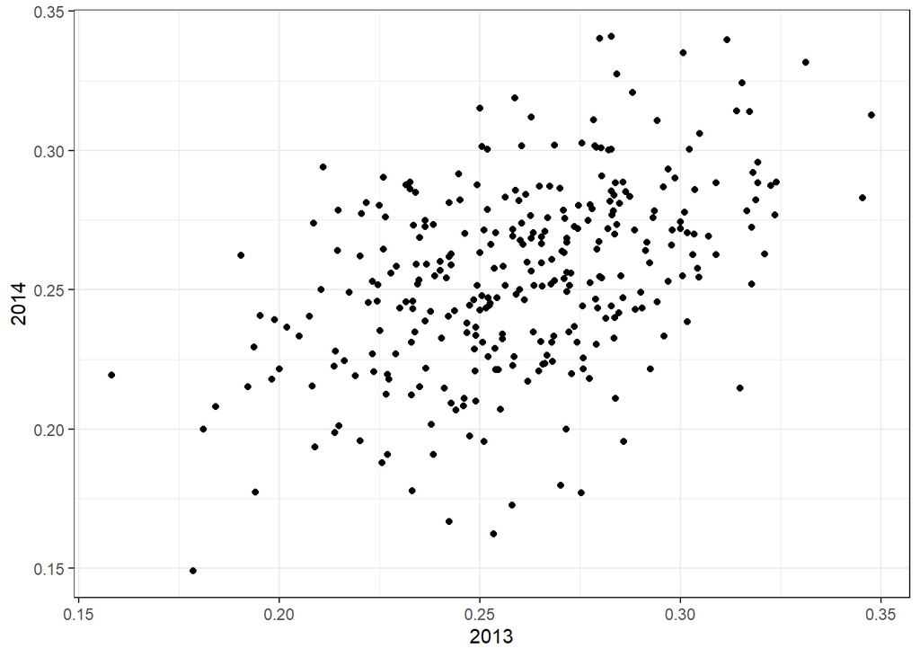

```r
qplot(`2013`, `2014`, data = two_years)
```

```r
summarize(two_years, cor(`2013`,`2014`))
```

```
## # A tibble: 1 x 1
##   `cor(\`2013\`, \`2014\`)`
##                       <dbl>
## 1                     0.460
```

## Measurement Error Models

The textbook for this section is available [here](https://rafalab.github.io/dsbook/linear-models.html#measurement-error-models)

**Key points**

- Up to now, all our linear regression examples have been applied to two or more random variables. We assume the pairs are bivariate normal and use this to motivate a linear model.
- Another use for linear regression is with **measurement error models**, where it is common to have a non-random covariate (such as time). Randomness is introduced from measurement error rather than sampling or natural variability.

*Code*

The code to use **dslabs** function **rfalling_object** to generate simulations of dropping balls:

```r
falling_object <- rfalling_object()
```

The code to draw the trajectory of the ball:

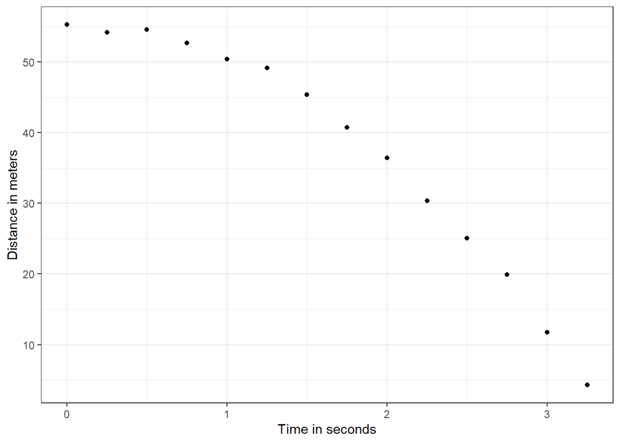

```r
falling_object %>%
    ggplot(aes(time, observed_distance)) +
    geom_point() +
    ylab("Distance in meters") +
    xlab("Time in seconds")
```

The code to use the `lm()` function to estimate the coefficients:

```r
fit <- falling_object %>%
    mutate(time_sq = time^2) %>%
    lm(observed_distance~time+time_sq, data=.)

tidy(fit)
```

```
## # A tibble: 3 x 5
##   term        estimate std.error statistic  p.value
##   <chr>          <dbl>     <dbl>     <dbl>    <dbl>
## 1 (Intercept)   55.0       0.434    127.   9.15e-19
## 2 time           0.888     0.620      1.43 1.80e- 1
## 3 time_sq       -5.08      0.184    -27.7  1.61e-11
```

The code to check if the estimated parabola fits the data:

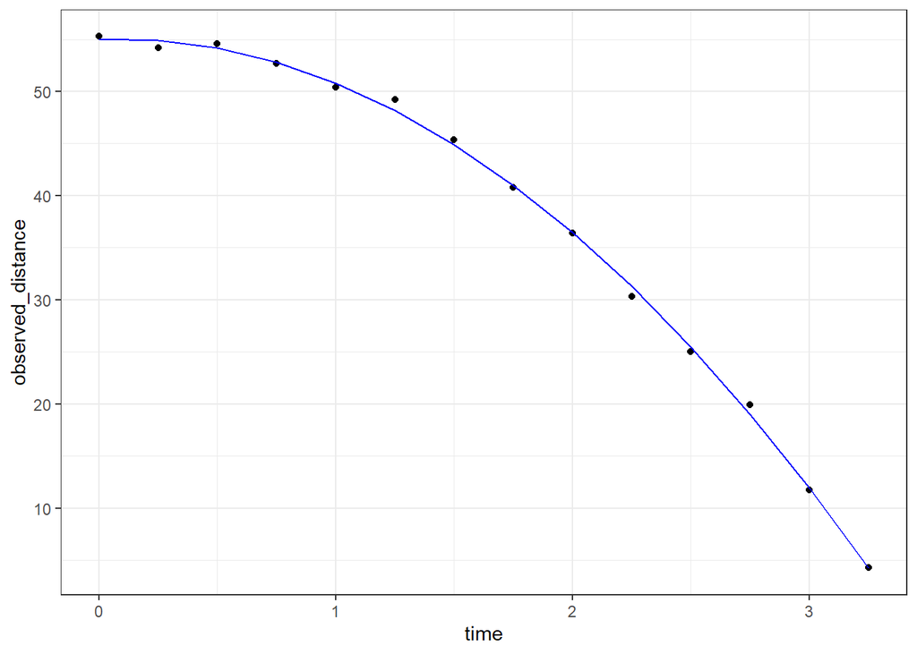

```r
augment(fit) %>%
    ggplot() +
    geom_point(aes(time, observed_distance)) +
    geom_line(aes(time, .fitted), col = "blue")
```

The code to see the summary statistic of the regression:

```r
tidy(fit, conf.int = TRUE)
```

```
## # A tibble: 3 x 7
##   term        estimate std.error statistic  p.value conf.low conf.high
##   <chr>          <dbl>     <dbl>     <dbl>    <dbl>    <dbl>     <dbl>
## 1 (Intercept)   55.0       0.434    127.   9.15e-19   54.1       56.0
## 2 time           0.888     0.620      1.43 1.80e- 1   -0.476      2.25
## 3 time_sq       -5.08      0.184    -27.7  1.61e-11   -5.49      -4.68
```

## Assessment - Regression and Baseball, part 1

1. What is the final linear model (in the video “Building a Better Offensive Metric for Baseball”) we used to predict runs scored per game?
- A. `lm(R ~ BB + HR)`
- B. `lm(HR ~ BB + singles + doubles + triples)`
- C. `lm(R ~ BB + singles + doubles + triples + HR)`
- D. `lm(R ~ singles + doubles + triples + HR)`
2. We want to estimate runs per game scored by individual players, not just by teams. What summary metric do we calculate to help estimate this?

Look at the code from the video “Building a Metter Offensive Metric for Baseball” for a hint:

```r
pa_per_game <- Batting %>%
  filter(yearID == 2002) %>%
  group_by(teamID) %>%
  summarize(pa_per_game = sum(AB+BB)/max(G)) %>%
  .$pa_per_game %>%
  mean
```

- A. `pa_per_game`: the mean number of plate appearances per team per game for each team
- B. `pa_per_game`: the mean number of plate appearances per game for each player
- C. `pa_per_game`: the number of plate appearances per team per game, averaged across all teams
3. Imagine you have two teams. Team A is comprised of batters who, on average, get two bases on balls, four singles, one double, and one home run. Team B is comprised of batters who, on average, get one base on balls, six singles, two doubles, and one triple.

Which team scores more runs, as predicted by our model?

- A. Team A
- B. Team B
- C. Tie
- D. Impossible to know
4. The on-base-percentage plus slugging percentage (OPS) metric gives the most weight to:
- A. Singles
- B. Doubles
- C. Triples
- D. Home Runs
5. What statistical concept properly explains the “sophomore slump”?
- A. Regression to the mean
- B. Law of averages
- C. Normal distribution
6. In our model of time vs. observed_distance in the video “Measurement Error Models”, the randomness of our data was due to:
- A. sampling
- B. natural variability
- C. measurement error
7. Which of the following are important assumptions about the measurement errors in this experiment?
- A. The measurement error is random
- B. The measurement error is independent
- C. The measurement error has the same distribution for each time i
8. Which of the following scenarios would violate an assumption of our measurement error model?
- A. The experiment was conducted on the moon.
- B. There was one position where it was particularly difficult to see the dropped ball.
- C. The experiment was only repeated 10 times, not 100 times.

## Assessment - Regression and Baseball, part 2

Question 9 has two parts. Use the information below to answer both parts.

Use the `Teams` data frame from the **Lahman** package. Fit a multivariate linear regression model to obtain the effects of BB and HR on Runs (**R**) in 1971. Use the `tidy()` function in the **broom** package to obtain the results in a data frame.

9a. What is the estimate for the effect of BB on runs?

```r
Teams %>%
    filter(yearID == 1971) %>%
    lm(R ~ BB + HR, data = .) %>%
    tidy() %>%
    filter(term == "BB") %>%
    pull(estimate)
```

```
## [1] 0.414
```

What is the estimate for the effect of HR on runs?

```r
Teams %>%
    filter(yearID == 1971) %>%
    lm(R ~ BB + HR, data = .) %>%
    tidy() %>%
    filter(term == "HR") %>%
    pull(estimate)
```

```
## [1] 1.3
```

9b. Interpret the p-values for the estimates using a cutoff of 0.05.

Which of the following is the correct interpretation?

```r
fit <- Teams %>% filter(yearID %in% 1971) %>%
mutate(BB = BB/G, HR = HR/G,  R = R/G) %>%
lm(R ~ BB + HR, data = .)

tidy(fit, conf.int = TRUE)
```

```
## # A tibble: 3 x 7
##   term        estimate std.error statistic p.value conf.low conf.high
##   <chr>          <dbl>     <dbl>     <dbl>   <dbl>    <dbl>     <dbl>
## 1 (Intercept)    1.60      0.665      2.40 0.0256    0.215      2.98
## 2 BB             0.412     0.203      2.03 0.0552   -0.0101     0.835
## 3 HR             1.29      0.427      3.03 0.00639   0.406      2.18
```

- A. Both BB and HR have a nonzero effect on runs.
- B. HR has a significant effect on runs, but the evidence is not strong enough to suggest BB also does.
- C. BB has a significant effect on runs, but the evidence is not strong enough to suggest HR also does.
- D. Neither BB nor HR have a statistically significant effect on runs.
10. Repeat the above exercise to find the effects of BB and HR on runs (`R`) for every year from 1961 to 2018 using `do()` and the **broom** package.

Make a scatterplot of the estimate for the effect of BB on runs over time and add a trend line with confidence intervals.

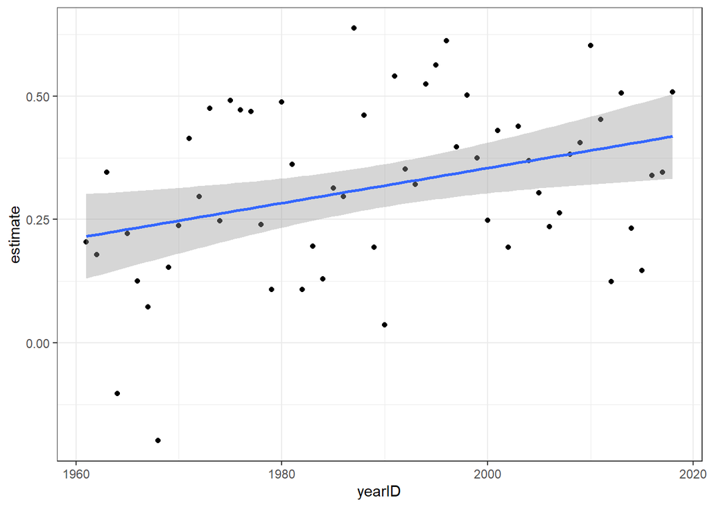

```r
res <- Teams %>%
    filter(yearID %in% 1961:2018) %>%
    group_by(yearID) %>%
    do(tidy(lm(R ~ BB + HR, data = .))) %>%
    ungroup()
res %>%
    filter(term == "BB") %>%
    ggplot(aes(yearID, estimate)) +
    geom_point() +
    geom_smooth(method = "lm")
```

Fill in the blank to complete the statement:

The effect of BB on runs has **increased** over time.

11. Fit a linear model on the results from Question 10 to determine the effect of year on the impact of BB.

For each additional year, by what value does the impact of BB on runs change?

```r
res %>%
    filter(term == "BB") %>%
    lm(estimate ~ yearID, data = .) %>%
    tidy() %>%
    filter(term == "yearID") %>%
    pull(estimate)
```

```
## [1] 0.00355
```

What is the p-value for this effect?

```r
res %>%
    filter(term == "BB") %>%
    lm(estimate ~ yearID, data = .) %>%
    tidy() %>%
    filter(term == "yearID") %>%
    pull(p.value)
```

```
## [1] 0.00807
```

## Assessment - Linear Models

This assessment has 6 multi-part questions that will all use the setup below.

Game attendance in baseball varies partly as a function of how well a team is playing.

Load the **Lahman** library. The `Teams` data frame contains an `attendance` column. This is the total attendance for the season. To calculate average attendance, divide by the number of games played, as follows:

```r
Teams_small <- Teams %>%
    filter(yearID %in% 1961:2001) %>%
    mutate(avg_attendance = attendance/G)
```

Use linear models to answer the following 3-part question about `Teams_small`.

1a. Use runs (`R`) per game to predict average attendance.

For every 1 run scored per game, average attendance increases by how much?

```r
# find regression line predicting attendance from R and take slope
Teams_small %>%
  mutate(R_per_game = R/G) %>%
  lm(avg_attendance ~ R_per_game, data = .) %>%
  .$coef %>%
  .[2]
```

```
## R_per_game
##       4117
```

Use home runs (`HR`) per game to predict average attendance.

For every 1 home run hit per game, average attendance increases by how much?

```r
Teams_small %>%
  mutate(HR_per_game = HR/G) %>%
  lm(avg_attendance ~ HR_per_game, data = .) %>%
  .$coef %>%
  .[2]
```

```
## HR_per_game
##        8113
```

1b. Use number of wins to predict average attendance; do not normalize for number of games.

For every game won in a season, how much does average attendance increase?

```r
Teams_small %>%
  lm(avg_attendance ~ W, data = .) %>%
  .$coef %>%
  .[2]
```

```
##   W
## 121
```

Suppose a team won zero games in a season.

Predict the average attendance.

```r
Teams_small %>%
  lm(avg_attendance ~ W, data = .) %>%
  .$coef %>%
  .[1]
```

```
## (Intercept)
##        1129
```

1c. Use year to predict average attendance.

How much does average attendance increase each year?

```r
Teams_small %>%
  lm(avg_attendance ~ yearID, data = .) %>%
  .$coef %>%
  .[2]
```

```
## yearID
##    244
```

2. Game wins, runs per game and home runs per game are positively correlated with attendance. We saw in the course material that runs per game and home runs per game are correlated with each other. Are wins and runs per game or wins and home runs per game correlated?

What is the correlation coefficient for wins and runs per game?

```r
cor(Teams_small$W, Teams_small$R/Teams_small$G)
```

```
## [1] 0.412
```

What is the correlation coefficient for wins and home runs per game?

```r
cor(Teams_small$W, Teams_small$HR/Teams_small$G)
```

```
## [1] 0.274
```

Stratify `Teams_small` by wins: divide number of wins by 10 and then round to the nearest integer. Keep only strata 5 through 10, which have 20 or more data points.

Use the stratified dataset to answer this three-part question.

3a. How many observations are in the 8 win strata? (Note that due to division and rounding, these teams have 75-85 wins.)

```r
dat <- Teams_small %>%
    mutate(W_strata = round(W/10)) %>%
    filter(W_strata >= 5 & W_strata <= 10)

sum(dat$W_strata == 8)
```

```
## [1] 338
```

3b. Calculate the slope of the regression line predicting average attendance given runs per game for each of the win strata.

Which win stratum has the largest regression line slope?

```r
# calculate slope of regression line after stratifying by R per game
dat %>%
  group_by(W_strata) %>%
  summarize(slope = cor(R/G, avg_attendance)*sd(avg_attendance)/sd(R/G))
```

```
## # A tibble: 6 x 2
##   W_strata slope
##      <dbl> <dbl>
## 1        5 4362.
## 2        6 4343.
## 3        7 3888.
## 4        8 3128.
## 5        9 3701.
## 6       10 3107.
```

- A. 5
- B. 6
- C. 7
- D. 8
- E. 9
- F. 10

Calculate the slope of the regression line predicting average attendance given HR per game for each of the win strata.

Which win stratum has the largest regression line slope?

```r
# calculate slope of regression line after stratifying by HR per game
dat %>%
  group_by(W_strata) %>%
  summarize(slope = cor(HR/G, avg_attendance)*sd(avg_attendance)/sd(HR/G))
```

```
## # A tibble: 6 x 2
##   W_strata  slope
##      <dbl>  <dbl>
## 1        5 10192.
## 2        6  7032.
## 3        7  8931.
## 4        8  6301.
## 5        9  5863.
## 6       10  4917.
```

- A. 5
- B. 6
- C. 7
- D. 8
- E. 9
- F. 10

3c. Which of the followng are true about the effect of win strata on average attendance?

- A. Across all win strata, runs per game are positively correlated with average attendance.
- B. Runs per game have the strongest effect on attendance when a team wins many games.
- C. After controlling for number of wins, home runs per game are not correlated with attendance.
- D. Home runs per game have the strongest effect on attendance when a team does not win many games.
- E. Among teams with similar numbers of wins, teams with more home runs per game have larger average attendance.
4. Fit a multivariate regression determining the effects of runs per game, home runs per game, wins, and year on average attendance. Use the original `Teams_small` wins column, not the win strata from question 3.

What is the estimate of the effect of runs per game on average attendance?

```r
fit <- Teams_small %>%
    mutate(R_per_game = R/G,
           HR_per_game = HR/G) %>%
    lm(avg_attendance ~ R_per_game + HR_per_game + W + yearID, data = .)
tidy(fit) %>%
    filter(term == "R_per_game") %>%
    pull(estimate)
```

```
## [1] 322
```

What is the estimate of the effect of home runs per game on average attendance?

```r
tidy(fit) %>%
    filter(term == "HR_per_game") %>%
    pull(estimate)
```

```
## [1] 1798
```

What is the estimate of the effect of number of wins in a season on average attendance?

```r
tidy(fit) %>%
    filter(term == "W") %>%
    pull(estimate)
```

```
## [1] 117
```

5. Use the multivariate regression model from Question 4. Suppose a team averaged 5 runs per game, 1.2 home runs per game, and won 80 games in a season.

What would this team’s average attendance be in 2002?

```r
predict(fit, data.frame(R_per_game = 5, HR_per_game = 1.2, W = 80, yearID = 2002))
```

```
##     1
## 16149
```

What would this team’s average attendance be in 1960?

```r
predict(fit, data.frame(R_per_game = 5, HR_per_game = 1.2, W = 80, yearID = 1960))
```

```
##    1
## 6505
```

6. Use your model from Question 4 to predict average attendance for teams in 2002 in the original Teams data frame.

What is the correlation between the predicted attendance and actual attendance?

```r
newdata <- Teams %>%
    filter(yearID == 2002) %>%
    mutate(avg_attendance = attendance/G,
           R_per_game = R/G,
           HR_per_game = HR/G)
preds <- predict(fit, newdata)
cor(preds, newdata$avg_attendance)
```

```
## [1] 0.519
```

# Section 3 - Confounding Overview

In the **Confounding** section, you will learn what is perhaps the most important lesson of statistics: that correlation is not causation.

After completing this section, you will be able to:

- Identify examples of **spurious correlation** and explain how **data dredging** can lead to spurious correlation.
- Explain how **outliers** can drive correlation and learn to adjust for outliers using **Spearman correlation**.
- Explain how **reversing cause and effect** can lead to associations being confused with causation.
- Understand how **confounders** can lead to the misinterpretation of associations.
- Explain and give examples of **Simpson’s Paradox**.

This section has one part: **Correlation is Not Causation**.

## Correlation is Not Causation: Spurious Correlation

The textbook for this section is available [here](https://rafalab.github.io/dsbook/association-is-not-causation.html#spurious-correlation)

**Key points**

- Association/correlation is not causation.
- p-hacking is a topic of much discussion because it is a problem in scientific publications. Because publishers tend to reward statistically significant results over negative results, there is an incentive to report significant results.

*Code*

```r
# generate the Monte Carlo simulation
N <- 25
g <- 1000000
sim_data <- tibble(group = rep(1:g, each = N), x = rnorm(N * g), y = rnorm(N * g))

# calculate correlation between X,Y for each group
res <- sim_data %>%
  group_by(group) %>%
  summarize(r = cor(x, y)) %>%
  arrange(desc(r))
res
```

```
## # A tibble: 1,000,000 x 2
##     group     r
##     <int> <dbl>
##  1 840003 0.794
##  2 767028 0.791
##  3 971856 0.776
##  4 212248 0.768
##  5  60200 0.761
##  6  27045 0.756
##  7 114409 0.756
##  8 755537 0.754
##  9 422986 0.753
## 10 789165 0.747
## # ... with 999,990 more rows
```

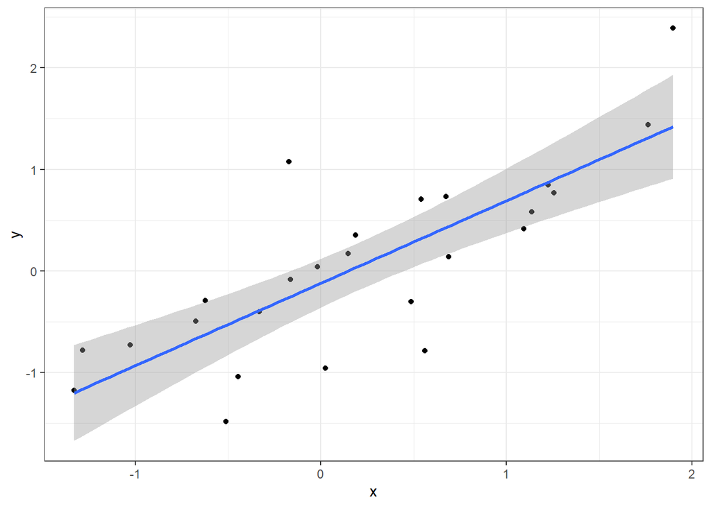

```r
# plot points from the group with maximum correlation
sim_data %>% filter(group == res$group[which.max(res$r)]) %>%
  ggplot(aes(x, y)) +
  geom_point() +
  geom_smooth(method = "lm")
```

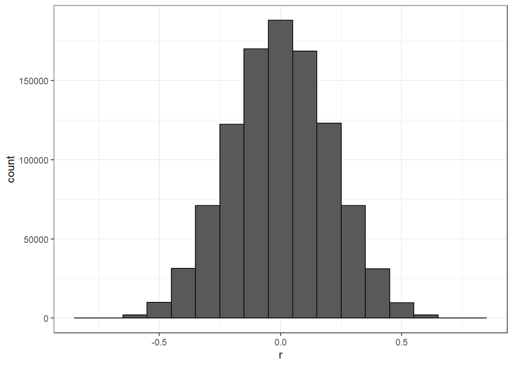

```r
# histogram of correlation in Monte Carlo simulations
res %>% ggplot(aes(x=r)) + geom_histogram(binwidth = 0.1, color = "black")
```

```r
# linear regression on group with maximum correlation
library(broom)
sim_data %>%
  filter(group == res$group[which.max(res$r)]) %>%
  do(tidy(lm(y ~ x, data = .)))
```

```
## # A tibble: 2 x 5
##   term        estimate std.error statistic    p.value
##   <chr>          <dbl>     <dbl>     <dbl>      <dbl>
## 1 (Intercept)   -0.121     0.116     -1.04 0.309
## 2 x              0.812     0.130      6.27 0.00000213
```

## Correlation is Not Causation: Outliers

The textbook for this section is available [here](https://rafalab.github.io/dsbook/association-is-not-causation.html#outliers-1)

**Key points**

- Correlations can be caused by **outliers**.
- The **Spearman correlation** is calculated based on the ranks of data.

*Code*

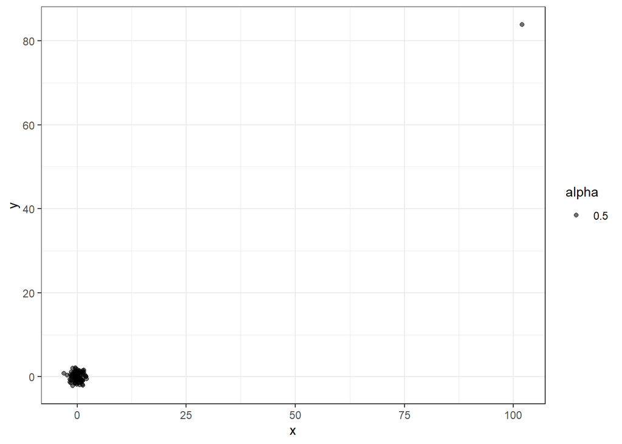

```r
# simulate independent X, Y and standardize all except entry 23
set.seed(1985)
x <- rnorm(100,100,1)
y <- rnorm(100,84,1)
x[-23] <- scale(x[-23])
y[-23] <- scale(y[-23])

# plot shows the outlier
qplot(x, y, alpha = 0.5)
```

```r
# outlier makes it appear there is correlation
cor(x,y)
```

```
## [1] 0.988
```

```r
cor(x[-23], y[-23])
```

```
## [1] -0.0442
```

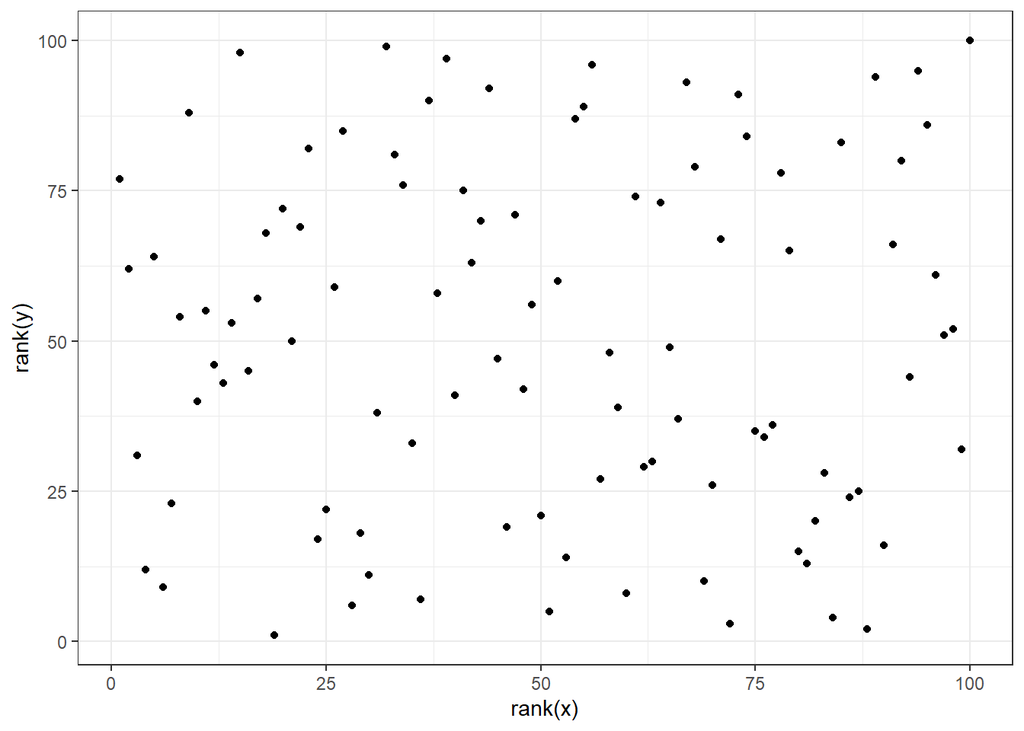

```r
# use rank instead
qplot(rank(x), rank(y))
```

```r
cor(rank(x), rank(y))
```

```
## [1] 0.00251
```

```r
# Spearman correlation with cor function
cor(x, y, method = "spearman")
```

```
## [1] 0.00251
```

## Correlation is Not Causation: Reversing Cause and Effect

The textbook for this section is available [here](https://rafalab.github.io/dsbook/association-is-not-causation.html#reversing-cause-and-effect)

**Key points**

- Another way association can be confused with causation is when the **cause and effect are reversed**.
- In the Galton data, when father and son were reversed in the regression, the model was technically correct. The estimates and p-values were obtained correctly as well. What was incorrect was the **interpretation** of the model.

*Code*

```r
# cause and effect reversal using son heights to predict father heights
data("GaltonFamilies")
GaltonFamilies %>%
  filter(childNum == 1 & gender == "male") %>%
  select(father, childHeight) %>%
  rename(son = childHeight) %>%
  do(tidy(lm(father ~ son, data = .)))
```

```
## # A tibble: 2 x 5
##   term        estimate std.error statistic  p.value
##   <chr>          <dbl>     <dbl>     <dbl>    <dbl>
## 1 (Intercept)   34.0      4.57        7.44 4.31e-12
## 2 son            0.499    0.0648      7.70 9.47e-13
```

## Correlation is Not Causation: Confounders

The textbook for this section is available [here](https://rafalab.github.io/dsbook/association-is-not-causation.html#confounders)

**Key points**

- If X and Y are correlated, we call Z a **confounder** if changes in Z causes changes in both X and Y.

*Code*

```r
# UC-Berkeley admission data
data(admissions)
admissions
```

```
##    major gender admitted applicants
## 1      A    men       62        825
## 2      B    men       63        560
## 3      C    men       37        325
## 4      D    men       33        417
## 5      E    men       28        191
## 6      F    men        6        373
## 7      A  women       82        108
## 8      B  women       68         25
## 9      C  women       34        593
## 10     D  women       35        375
## 11     E  women       24        393
## 12     F  women        7        341
```

```r
# percent men and women accepted
admissions %>% group_by(gender) %>%
  summarize(percentage =
              round(sum(admitted*applicants)/sum(applicants),1))
```

```
## # A tibble: 2 x 2
##   gender percentage
##   <chr>       <dbl>
## 1 men          44.5
## 2 women        30.3
```

```r
# test whether gender and admission are independent
admissions %>% group_by(gender) %>%
  summarize(total_admitted = round(sum(admitted / 100 * applicants)),
            not_admitted = sum(applicants) - sum(total_admitted)) %>%
  select(-gender) %>%
  do(tidy(chisq.test(.)))
```

```
## # A tibble: 1 x 4
##   statistic  p.value parameter method
##       <dbl>    <dbl>     <int> <chr>
## 1      91.6 1.06e-21         1 Pearson's Chi-squared test with Yates' continuit~
```

```r
# percent admissions by major
admissions %>% select(major, gender, admitted) %>%
  spread(gender, admitted) %>%
  mutate(women_minus_men = women - men)
```

```
##   major men women women_minus_men
## 1     A  62    82              20
## 2     B  63    68               5
## 3     C  37    34              -3
## 4     D  33    35               2
## 5     E  28    24              -4
## 6     F   6     7               1
```

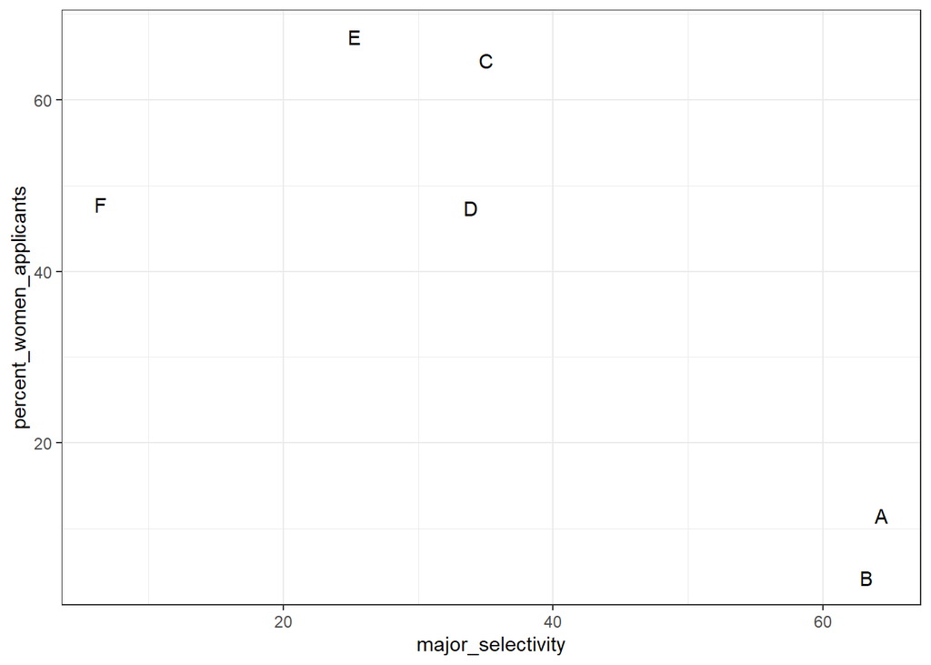

```r
# plot total percent admitted to major versus percent women applicants
admissions %>%
  group_by(major) %>%
  summarize(major_selectivity = sum(admitted * applicants) / sum(applicants),
            percent_women_applicants = sum(applicants * (gender=="women")) /
                                             sum(applicants) * 100) %>%
  ggplot(aes(major_selectivity, percent_women_applicants, label = major)) +
  geom_text()
```

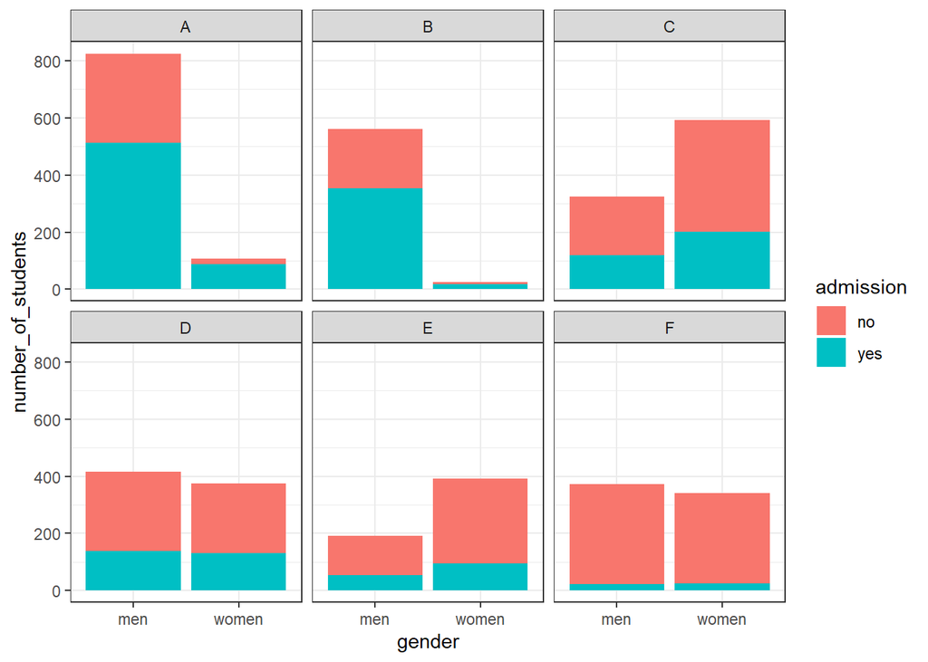

```r
# plot number of applicants admitted and not
admissions %>%
  mutate(yes = round(admitted/100*applicants), no = applicants - yes) %>%
  select(-applicants, -admitted) %>%
  gather(admission, number_of_students, -c("major", "gender")) %>%
  ggplot(aes(gender, number_of_students, fill = admission)) +
  geom_bar(stat = "identity", position = "stack") +
  facet_wrap(. ~ major)
```

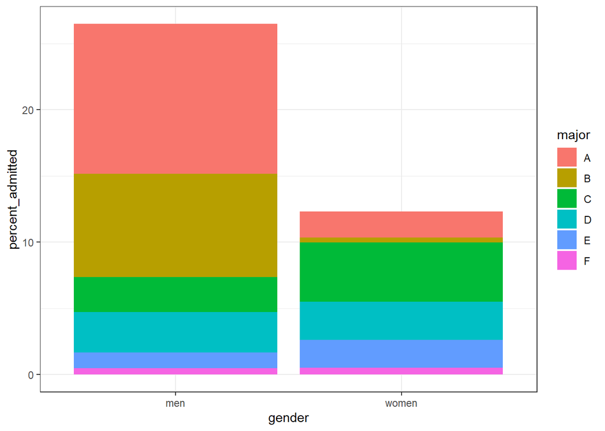

```r
admissions %>%
  mutate(percent_admitted = admitted * applicants/sum(applicants)) %>%
  ggplot(aes(gender, y = percent_admitted, fill = major)) +
  geom_bar(stat = "identity", position = "stack")
```

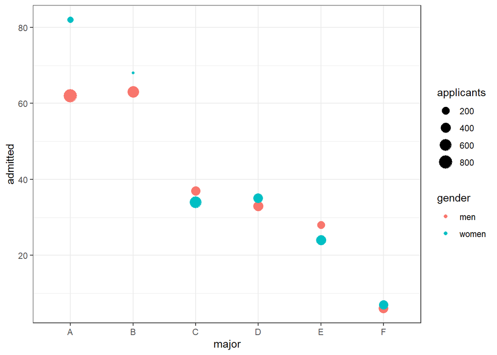

```r
# condition on major and then look at differences
admissions %>% ggplot(aes(major, admitted, col = gender, size = applicants)) + geom_point()
```

```r
# average difference by major
admissions %>%  group_by(gender) %>% summarize(average = mean(admitted))
```

```
## # A tibble: 2 x 2
##   gender average
##   <chr>    <dbl>
## 1 men       38.2
## 2 women     41.7
```

## Simpson’s Paradox

The textbook for this section is available [here](https://rafalab.github.io/dsbook/association-is-not-causation.html#simpsons-paradox)

**Key point**

- Simpson’s Paradox happens when we see the sign of the correlation flip when comparing the entire dataset with specific strata.

## Assessment - Correlation is Not Causation

1. In the video, we ran one million tests of correlation for two random variables, X and Y.

- A. 5,000
- B. 50,000
- C. 100,000
- D. It’s impossible to know

The chance of finding a correlation when none exists is $0.05*1.000.000$ chances

2. Which of the following are examples of p-hacking?
- A. Looking for associations between an outcome and several exposures and only reporting the one that is significant.
- B. Trying several different models and selecting the one that yields the smallest p-value.
- C. Repeating an experiment multiple times and only reporting the one with the smallest p-value.
- D. Using a Monte Carlo simulations in an analysis.
3. The Spearman correlation coefficient is robust to outliers because:
- A. It drops outliers before calculating correlation.
- B. It is the correlation of standardized values.
- C. It calculates correlation between ranks, not values.
4. What can you do to determine if you are misinterpreting results because of a confounder?
- A. Nothing, if the p-value says the result is significant, then it is.
- B. More closely examine the results by stratifying and plotting the data.
- C. Always assume that you are misinterpreting the results.
- D. Use linear models to tease out a confounder.
5. Look again at the admissions data using ?admissions. What important characteristic of the table variables do you need to know to understand the calculations used in this video? Select the best answer.
- A. The data is from 1973.
- B. The columns “major” and “gender” are of class character, while “admitted” and “applicants” are numeric.
- C. The data is from the “dslabs” package.
- D. The column “admitted” is the percent of student admitted, while the column “applicants” is the total number of applicants.
6. In the example in the video, major selectivity confounds the relationship between UC Berkley admission rates and gender because:
- A. It was harder for women to be admitted to UC Berkeley.
- B. Major selectivity is associated with both admission rates and with gender, as women tended to apply to more selective majors.
- C. Some majors are more selective than others
- D. Major selectivity is not a confounder.
7. Admission rates at UC Berkeley are an example of Simpson’s Paradox because:
- A. It appears that men have higher a higher admission rate than women, however, after we stratify by major, we see that on average women have a higher admission rate than men.
- B. It was a paradox that women were being admitted at a lower rate than men.
- C. The relationship between admissions and gender is confounded by major selectivity.

## Assessment - Confounding

For this set of exercises, we examine the data from a [2014 PNAS paper that analyzed success rates from funding agencies in the Netherlands](https://www.pnas.org/content/112/40/12349.abstract) and concluded:

*“our results reveal gender bias favoring male applicants over female applicants in the prioritization of their”quality of researcher" (but not “quality of proposal”) evaluations and success rates, as well as in the language used in instructional and evaluation materials."*

A response was published a few months later titled [No evidence that gender contributes to personal research funding success in The Netherlands: A reaction to Van der Lee and Ellemers](https://www.pnas.org/content/112/51/E7036), which concluded:

*However, the overall gender effect borders on statistical significance, despite the large sample. Moreover, their conclusion could be a prime example of Simpson’s paradox; if a higher percentage of women apply for grants in more competitive scientific disciplines (i.e., with low application success rates for both men and women), then an analysis across all disciplines could incorrectly show “evidence” of gender inequality.*

Who is right here: the original paper or the response? Here, you will examine the data and come to your own conclusion.

The main evidence for the conclusion of the original paper comes down to a comparison of the percentages. The information we need was originally in Table S1 in the paper, which we include in **dslabs**:

```r
data("research_funding_rates")
research_funding_rates
```

```
##            discipline applications_total applications_men applications_women
## 1   Chemical sciences                122               83                 39
## 2   Physical sciences                174              135                 39
## 3             Physics                 76               67                  9
## 4          Humanities                396              230                166
## 5  Technical sciences                251              189                 62
## 6   Interdisciplinary                183              105                 78
## 7 Earth/life sciences                282              156                126
## 8     Social sciences                834              425                409
## 9    Medical sciences                505              245                260
##   awards_total awards_men awards_women success_rates_total success_rates_men
## 1           32         22           10                26.2              26.5
## 2           35         26            9                20.1              19.3
## 3           20         18            2                26.3              26.9
## 4           65         33           32                16.4              14.3
## 5           43         30           13                17.1              15.9
## 6           29         12           17                15.8              11.4
## 7           56         38           18                19.9              24.4
## 8          112         65           47                13.4              15.3
## 9           75         46           29                14.9              18.8
##   success_rates_women
## 1                25.6
## 2                23.1
## 3                22.2
## 4                19.3
## 5                21.0
## 6                21.8
## 7                14.3
## 8                11.5
## 9                11.2
```

1. Construct a two-by-two table of gender (men/women) by award status (awarded/not) using the total numbers across all disciplines.

What is the number of men not awarded?

What is the number of women not awarded?

```r
two_by_two <- research_funding_rates %>%
    select(-discipline) %>%
    summarize_all(funs(sum)) %>%
    summarize(yes_men = awards_men,
              no_men = applications_men - awards_men,
              yes_women = awards_women,
              no_women = applications_women - awards_women) %>%
    gather %>%
    separate(key, c("awarded", "gender")) %>%
    spread(gender, value)
  two_by_two
```

```
##   awarded  men women
## 1      no 1345  1011
## 2     yes  290   177
```

2. Use the two-by-two table from Question 1 to compute the percentages of men awarded versus women awarded.

What is the percentage of men awarded?

```r
two_by_two %>%
    mutate(men = round(men/sum(men)*100, 1), women = round(women/sum(women)*100, 1)) %>%
    filter(awarded == "yes") %>%
    pull(men)
```

```
## [1] 17.7
```

What is the percentage of women awarded?

```r
two_by_two %>%
    mutate(men = round(men/sum(men)*100, 1), women = round(women/sum(women)*100, 1)) %>%
    filter(awarded == "yes") %>%
    pull(women)
```

```
## [1] 14.9
```

3. Run a chi-squared test on the two-by-two table to determine whether the difference in the two success rates is significant. (You can use `tidy()` to turn the output of `chisq.test()` into a data frame as well.)

What is the p-value of the difference in funding rate?

```r
two_by_two %>% select(-awarded) %>% chisq.test() %>% tidy() %>% pull(p.value)
```

```
## [1] 0.0509
```

4. There may be an association between gender and funding. But can we infer causation here? Is gender bias causing this observed difference? The response to the original paper claims that what we see here is similar to the UC Berkeley admissions example. Specifically they state that this “could be a prime example of Simpson’s paradox; if a higher percentage of women apply for grants in more competitive scientific disciplines, then an analysis across all disciplines could incorrectly show ‘evidence’ of gender inequality.”

To settle this dispute, use this dataset with number of applications, awards, and success rate for each gender:

```r
dat <- research_funding_rates %>%
      mutate(discipline = reorder(discipline, success_rates_total)) %>%
      rename(success_total = success_rates_total,
             success_men = success_rates_men,
             success_women = success_rates_women) %>%
      gather(key, value, -discipline) %>%
      separate(key, c("type", "gender")) %>%
      spread(type, value) %>%
      filter(gender != "total")
dat
```

```
##             discipline gender applications awards success
## 1      Social sciences    men          425     65    15.3
## 2      Social sciences  women          409     47    11.5
## 3     Medical sciences    men          245     46    18.8
## 4     Medical sciences  women          260     29    11.2
## 5    Interdisciplinary    men          105     12    11.4
## 6    Interdisciplinary  women           78     17    21.8
## 7           Humanities    men          230     33    14.3
## 8           Humanities  women          166     32    19.3
## 9   Technical sciences    men          189     30    15.9
## 10  Technical sciences  women           62     13    21.0
## 11 Earth/life sciences    men          156     38    24.4
## 12 Earth/life sciences  women          126     18    14.3
## 13   Physical sciences    men          135     26    19.3
## 14   Physical sciences  women           39      9    23.1
## 15   Chemical sciences    men           83     22    26.5
## 16   Chemical sciences  women           39     10    25.6
## 17             Physics    men           67     18    26.9
## 18             Physics  women            9      2    22.2
```

To check if this is a case of Simpson’s paradox, plot the success rates versus disciplines, which have been ordered by overall success, with colors to denote the genders and size to denote the number of applications.

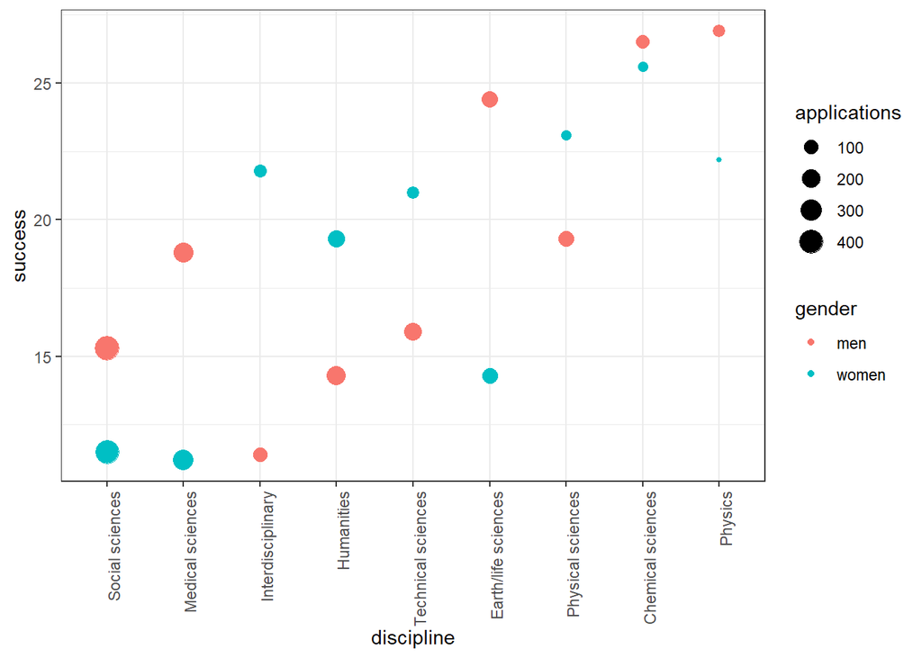

```r
dat %>%
      ggplot(aes(discipline, success, size = applications, color = gender)) +
      theme(axis.text.x = element_text(angle = 90, hjust = 1)) +
      geom_point()
```

In which fields do men have a higher success rate than women?

- A. Chemical sciences
- B. Earth/life sciences
- C. Humanities
- D. Interdisciplinary
- E. Medical sciences
- F. Physical sciences
- G. Physics
- H. Social sciences
- I. Technical sciences

Which two fields have the most applications from women?

- A. Chemical sciences
- B. Earth/life sciences
- C. Humanities
- D. Interdisciplinary
- E. Medical sciences
- F. Physical sciences
- G. Physics
- H. Social sciences
- I. Technical sciences

Which two fields have the lowest overall funding rates?

- A. Chemical sciences
- B. Earth/life sciences
- C. Humanities
- D. Interdisciplinary
- E. Medical sciences
- F. Physical sciences
- G. Physics
- H. Social sciences
- I. Technical sciences